## Course: COMPUTATIONAL THINKING FOR GOVERNANCE ANALYTICS

### Prof. José Manuel Magallanes, PhD

- Visiting Professor of Computational Policy at Evans School of Public Policy and Governance, and eScience Institute Senior Data Science Fellow, University of Washington.
- Professor of Government and Political Methodology, Pontificia Universidad Católica del Perú.

# Dimensionality Reduction in R

As the name implies, we want to *reduce* a set of variables into one (or two) that summarizes them. In this session we will practice two basic techniques:

- Cluster analysis.
- Factor analysis.

## Cluster Analysis

Simply speaking, this technique will organize the cases (rows) into a small set of groups, based on the information (the columns) available for each case.

Let me bring back the data we prepared in Python:

```r
rm(list = ls())
link='https://github.com/EvansDataScience/CTforGA_integrating/raw/main/demo_fragile.RDS'
# a RDS file from the web needs:
myFile=url(link)

# reading in data:
fromPy=readRDS(file = myFile)

# reset indexes to R format:
row.names(fromPy)=NULL

# check data types
str(fromPy)
```

```
## 'data.frame':    165 obs. of  20 variables:
##  $ Country                     : chr  "Norway" "New Zealand" "Finland" "Sweden" ...
##  $ Regimetype                  : Ord.factor w/ 3 levels "Authoritarian"<..: 3 3 3 3 3 3 3 3 3 3 ...
##  $ Overallscore                : num  9.75 9.37 9.27 9.26 9.18 9.09 9 8.9 8.9 8.88 ...
##  $ Electoralprocessandpluralism: num  10 10 10 9.58 10 10 10 10 9.58 9.58 ...
##  $ Functioningofgovernment     : num  9.64 8.93 9.29 9.29 8.21 8.93 7.86 8.57 8.93 8.93 ...
##  $ Politicalparticipation      : num  10 9.44 8.89 8.33 8.89 8.33 8.33 7.78 7.78 8.33 ...
##  $ Politicalculture            : num  10 8.75 8.75 10 9.38 9.38 9.38 8.75 9.38 8.75 ...
##  $ Civilliberties              : num  9.12 9.71 9.41 9.12 9.41 8.82 9.41 9.41 8.82 8.82 ...
##  $ C1SecurityApparatus         : num  1.8 1.4 2.5 2.7 0.7 1.7 2.7 2.7 1.6 2.2 ...
##  $ C2FactionalizedElites       : num  1.1 1.4 1.4 1.8 1.8 1.4 1.5 1.7 1 3.4 ...
##  $ C3GroupGrievance            : num  3.3 2.6 0.6 1.7 0.5 3.7 0.5 3.1 2.7 3.6 ...
##  $ E1Economy                   : num  1.9 3.4 2.9 1.9 3.4 1.7 2.7 1.6 2 2.2 ...
##  $ E2EconomicInequality        : num  1 2.1 1 1.7 1.3 1.2 1.6 1.8 1.8 1.6 ...
##  $ E3HumanFlightandBrainDrain  : num  0.8 1.6 1.5 0.7 1.9 1.3 2.8 0.5 1.1 2.4 ...
##  $ P1StateLegitimacy           : num  0.5 0.5 0.5 0.5 0.5 0.5 0.5 0.5 0.5 0.5 ...
##  $ P2PublicServices            : num  1.6 1.4 1.6 1.4 1.2 1.4 2.5 2.8 1.6 1.3 ...
##  $ P3HumanRights               : num  0.5 0.5 0.5 0.9 0.5 0.9 1.6 1.7 0.8 0.7 ...
##  $ S1DemographicPressures      : num  1.4 1.4 1.7 3.3 1.5 2.3 2.8 2.9 3.2 3.1 ...
##  $ S2RefugeesandIDPs           : num  2.2 1.6 1.5 4.3 1.5 2.2 1.4 2 3.1 2.6 ...
##  $ X1ExternalIntervention      : num  0.5 0.5 0.5 0.5 3.2 0.5 1.6 0.5 0.5 0.5 ...
```

### I. Prepare data:

We have several countries, and several columns. In clustering, we try to create groups so that we have the highest homogeneity within groups, and the highest heterogeneity between groups. The variables will serve to try to find the homogeneity and heterogeneity mentioned, that is, some **distance** among them. Let’s do that first:

1. Subset the data: For this case just keep the columns with numeric values without the categories or the summary scores:

```r
dataToCluster=fromPy[,-c(1:3)]
row.names(dataToCluster)=fromPy$Country
```

2. Decide if standardizing is needed: Take a look at the data ranges:

```r
summary(dataToCluster)
```

```
##  Electoralprocessandpluralism Functioningofgovernment Politicalparticipation
##  Min.   : 0.000               Min.   :0.000           Min.   : 0.000
##  1st Qu.: 1.420               1st Qu.:2.500           1st Qu.: 3.890
##  Median : 7.000               Median :5.000           Median : 5.560
##  Mean   : 5.619               Mean   :4.616           Mean   : 5.377
##  3rd Qu.: 9.170               3rd Qu.:6.430           3rd Qu.: 6.670
##  Max.   :10.000               Max.   :9.640           Max.   :10.000
##  Politicalculture Civilliberties  C1SecurityApparatus C2FactionalizedElites
##  Min.   : 1.250   Min.   :0.000   Min.   : 0.500      Min.   : 1.000
##  1st Qu.: 3.750   1st Qu.:3.240   1st Qu.: 3.500      1st Qu.: 5.100
##  Median : 5.000   Median :5.590   Median : 5.600      Median : 7.300
##  Mean   : 5.351   Mean   :5.326   Mean   : 5.294      Mean   : 6.601
##  3rd Qu.: 6.250   3rd Qu.:7.650   3rd Qu.: 6.900      3rd Qu.: 8.400
##  Max.   :10.000   Max.   :9.710   Max.   :10.000      Max.   :10.000
##  C3GroupGrievance   E1Economy     E2EconomicInequality
##  Min.   :0.500    Min.   :1.200   Min.   :1.000
##  1st Qu.:4.000    1st Qu.:4.400   1st Qu.:3.600
##  Median :5.800    Median :5.900   Median :5.200
##  Mean   :5.758    Mean   :5.778   Mean   :5.255
##  3rd Qu.:7.500    3rd Qu.:7.100   3rd Qu.:7.100
##  Max.   :9.900    Max.   :9.800   Max.   :9.600
##  E3HumanFlightandBrainDrain P1StateLegitimacy P2PublicServices P3HumanRights
##  Min.   :0.500              Min.   : 0.500    Min.   : 1.200   Min.   :0.500
##  1st Qu.:3.800              1st Qu.: 3.700    1st Qu.: 3.700   1st Qu.:3.400
##  Median :5.500              Median : 6.400    Median : 5.400   Median :6.000
##  Mean   :5.212              Mean   : 5.817    Mean   : 5.719   Mean   :5.447
##  3rd Qu.:6.800              3rd Qu.: 8.200    3rd Qu.: 8.000   3rd Qu.:7.400
##  Max.   :9.000              Max.   :10.000    Max.   :10.000   Max.   :9.800
##  S1DemographicPressures S2RefugeesandIDPs X1ExternalIntervention
##  Min.   :1.400          Min.   : 0.700    Min.   : 0.500
##  1st Qu.:4.100          1st Qu.: 2.800    1st Qu.: 3.400
##  Median :5.700          Median : 4.300    Median : 5.400
##  Mean   :5.901          Mean   : 4.802    Mean   : 5.124
##  3rd Qu.:8.000          3rd Qu.: 6.600    3rd Qu.: 6.900
##  Max.   :9.800          Max.   :10.000    Max.   :10.000
```

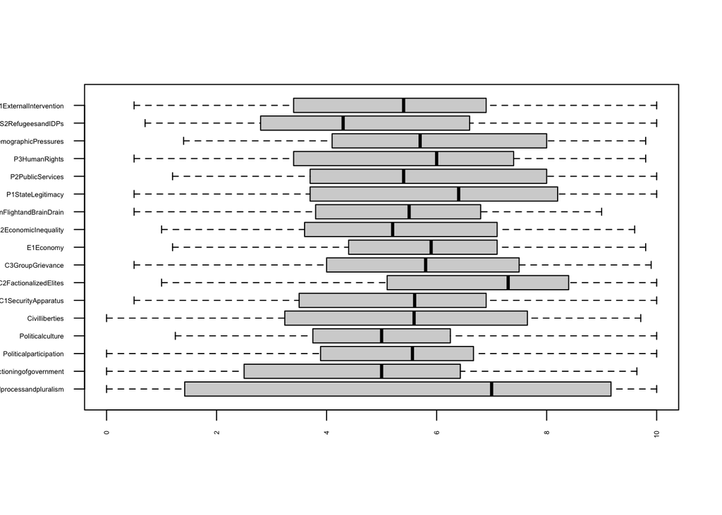

```r
boxplot(dataToCluster,horizontal = T, las=2,cex.axis=0.4)
```

The data values have a similar range, then you do not need to transform the data. Possible alternatives could have been:

```r
#### standardizing
normalize(dataToCluster,method='standardize')

### normalizing
normalize(dataToCluster,method='range',range=c(0,10))
```

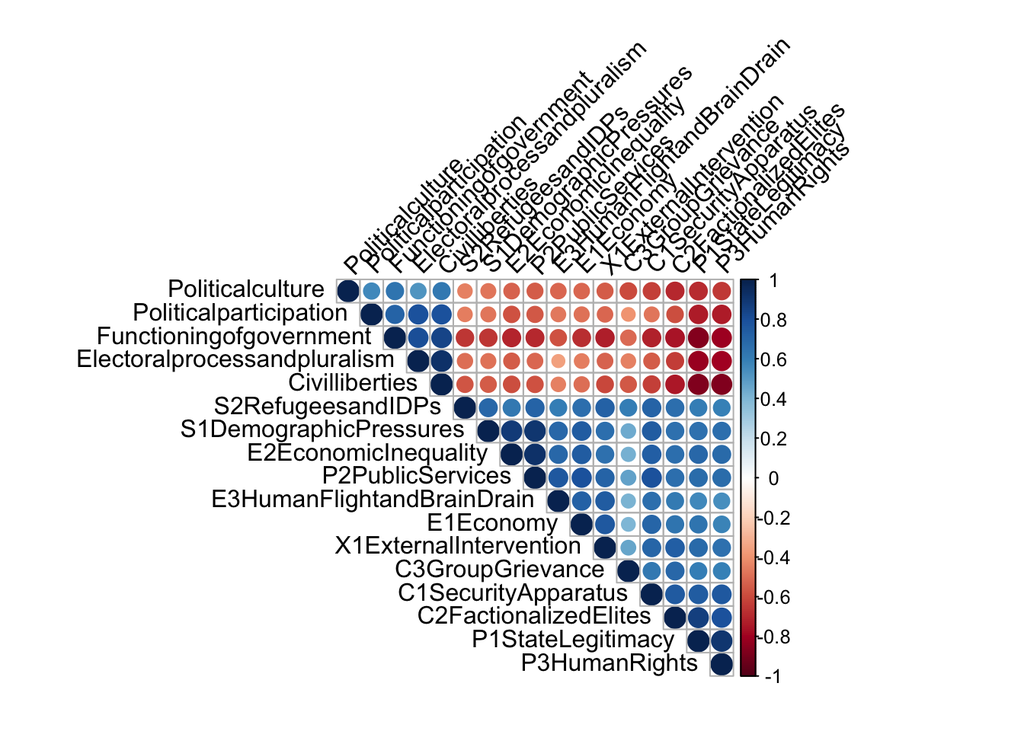

```r
library(corrplot)
res <- cor(dataToCluster)
corrplot(res, type = "upper", order = "hclust",
         tl.col = "black", tl.srt = 45)
```

### II. Compute the DISTANCE MATRIX:

3. Set random seed:

```r
set.seed(999) # this is for replicability of results
```

4. Decide distance method and compute distance matrix:

```r
library(cluster)
distancesData=daisy(x=dataToCluster, metric = "gower")
```

5. Represent distances

We can prepare a bidimensional map. The function *cmdscale* can produce a two dimension map of points using the *distance matrix*:

```r
projectedData = cmdscale(distancesData, k=2)
```

The object projectedData is saving coordinates for each element in the data:

```r
#
# save coordinates to original data frame:
fromPy$dim1 = projectedData[,1]
fromPy$dim2 = projectedData[,2]

# see some:

fromPy[,c('dim1','dim2')][1:10,]
```

```
##          dim1         dim2
## 1  -0.4637066 -0.017476271
## 2  -0.4374335 -0.016755363
## 3  -0.4492530 -0.017650599
## 4  -0.4115496  0.002026328
## 5  -0.4318327 -0.012772446
## 6  -0.4280394 -0.017597666
## 7  -0.3980438 -0.013114093
## 8  -0.4004756 -0.016744500
## 9  -0.4125417 -0.010853684
## 10 -0.3835142 -0.011989627
```

- Use those points and see the “map”:

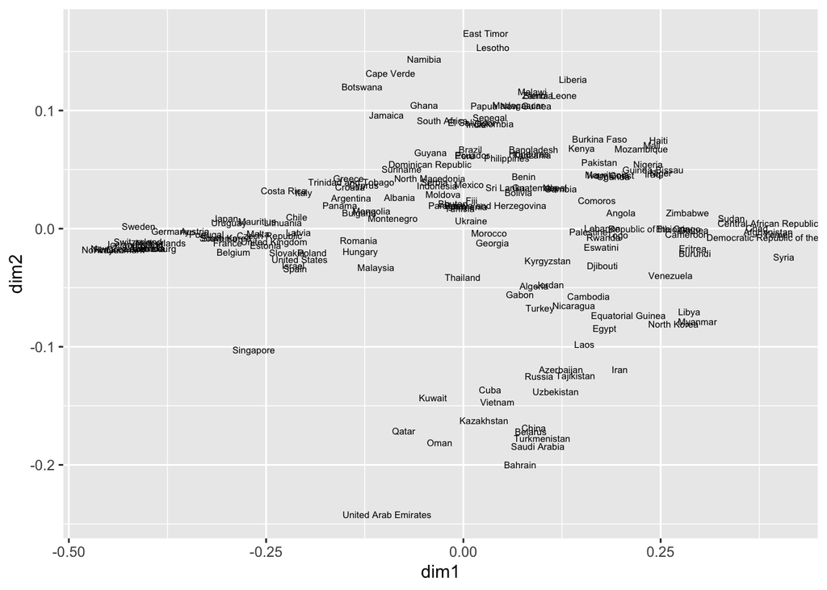

```r
library(ggplot2)
base= ggplot(data=fromPy,
             aes(x=dim1, y=dim2,
                 label=Country))
base + geom_text(size=2)
```

Do you see some groups emerge?

An alternative is the dendogram:

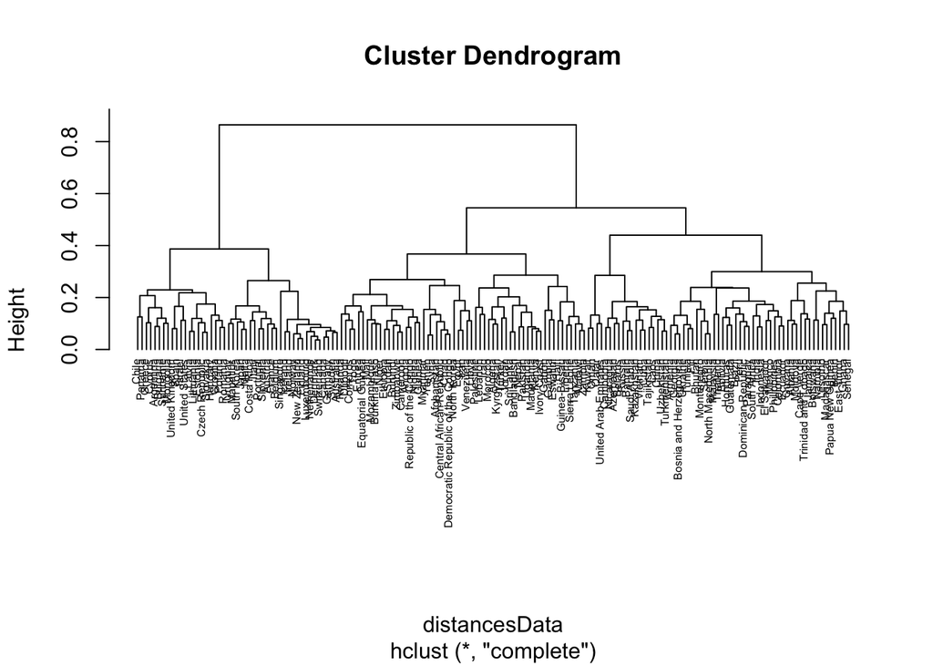

```r
# prepare hierarchical cluster
hc = hclust(distancesData)
# very simple dendrogram
plot(hc,hang = -1,cex=0.5)
```

## Compute Clusters

### 0. Computer suggestions

Using function *fviz_nbclust* from the library *factoextra* we can see how many clustered are suggested.

1. For hierarchical (agglomerative):

```r
library(factoextra)
```

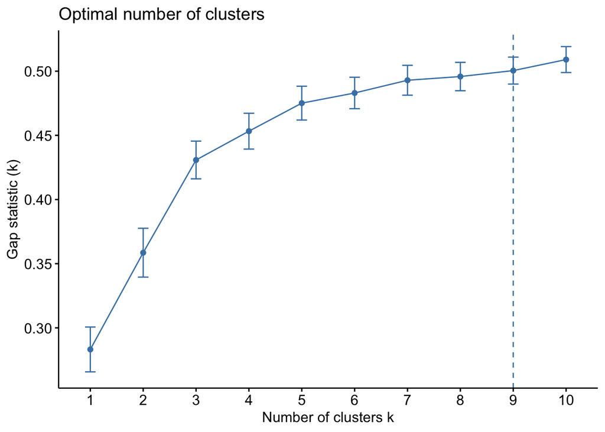

```r
fviz_nbclust(dataToCluster,
             hcut,
             diss=distancesData,
             method = "gap_stat",
             k.max = 10,
             verbose = F,
             hc_func = "agnes")
```

3. For hierarchical (divisive):

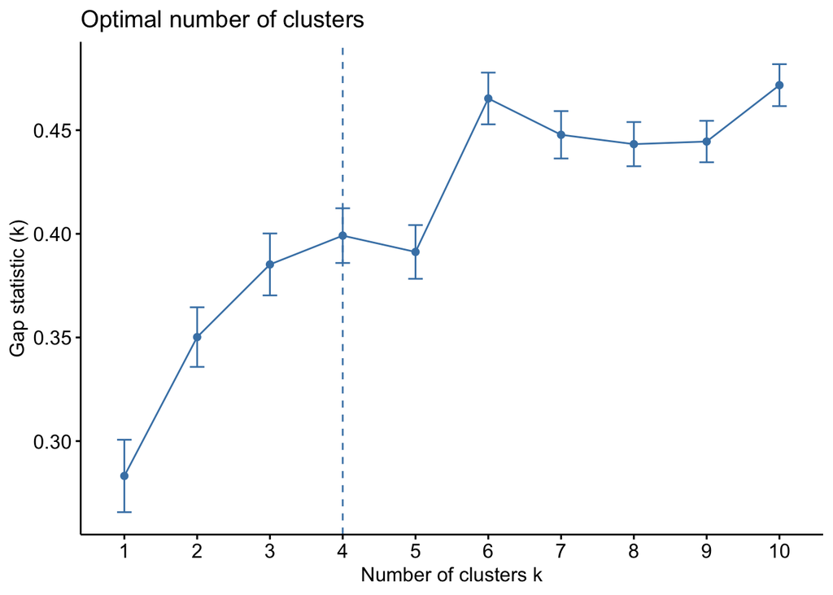

```r
fviz_nbclust(dataToCluster,
             hcut,
             diss=distancesData,
             method = "gap_stat",
             k.max = 10,
             verbose = F,
             hc_func = "diana")
```

### 1. Apply function: you need to indicate a priori the amount of clusters required.

```r
NumberOfClusterDesired=4


#library(factoextra)
res.agnes= hcut(distancesData,
                k = NumberOfClusterDesired,
                isdiss=TRUE,
                hc_func='agnes',
                hc_method = "ward.D2")

# Hierarchical technique- divisive approach
res.diana= hcut(distancesData,
                k = NumberOfClusterDesired,
                isdiss=TRUE,
                hc_func='diana',
                hc_method = "ward.D2")
```

### 2. Clustering results.

**2.1** Add results to original data frame:

```r
fromPy$agn=as.factor(res.agnes$cluster)
fromPy$dia=as.factor(res.diana$cluster)
```

**2.2** Verify ordinality in clusters

```r
aggregate(data=fromPy,
          Overallscore~agn,
          FUN=mean)
```

```
##   agn Overallscore
## 1   1     8.082250
## 2   2     6.272222
## 3   3     3.503220
## 4   4     2.627143
```

```r
aggregate(data=fromPy,
          Overallscore~dia,
          FUN=mean)
```

```
##   dia Overallscore
## 1   1     8.309118
## 2   2     6.553333
## 3   3     5.128333
## 4   4     2.843019
```

You could recode these values like this:

```r
library(dplyr)
fromPy$agn=dplyr::recode_factor(fromPy$agn,
                  `1` = '4',`2`='3',`3`='2',`4`='1')
fromPy$dia=dplyr::recode_factor(fromPy$dia,
                  `1` = '4',`2`='3',`3`='2',`4`='1')
```

### 3. Evaluate Results.

**3.1** Plot silhouettes

```
##   cluster size ave.sil.width
## 1       1   40          0.42
## 2       2   45          0.25
## 3       3   59          0.19
## 4       4   21          0.34
```

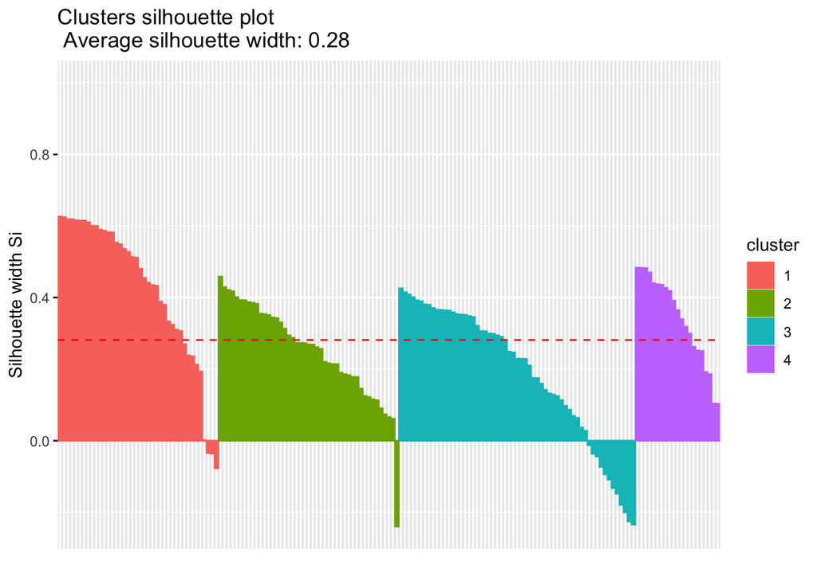

```r
fviz_silhouette(res.agnes)
```

```
##   cluster size ave.sil.width
## 1       1   34          0.36
## 2       2   24          0.14
## 3       3   54          0.13
## 4       4   53          0.27
```

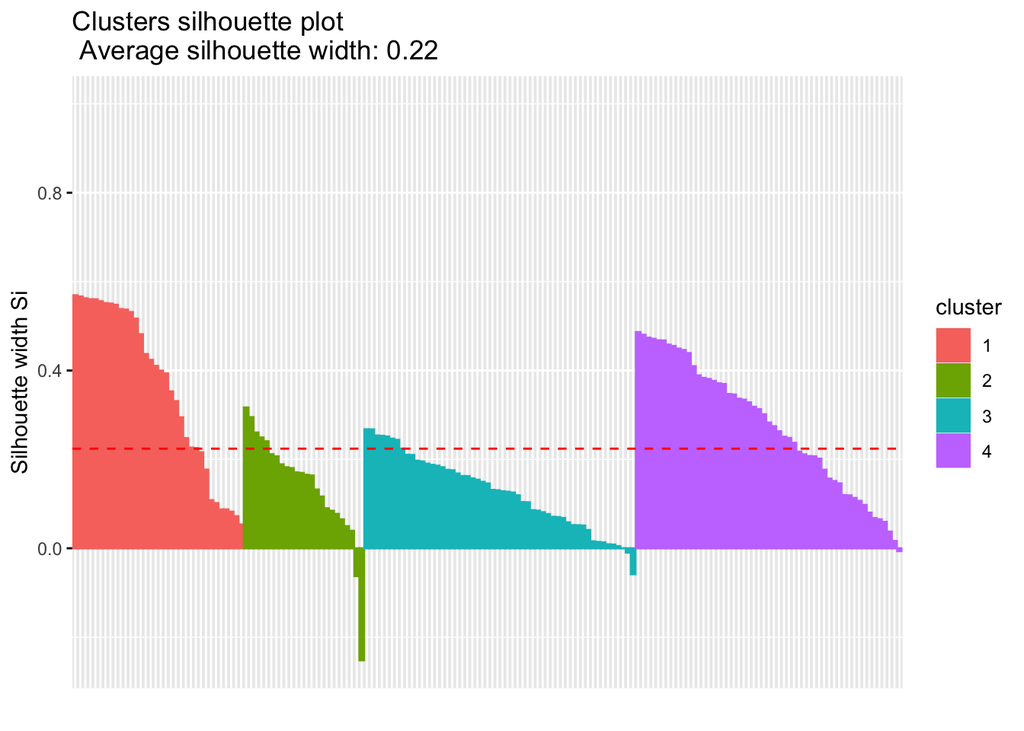

```r
library(factoextra)
fviz_silhouette(res.diana)
```

**3.2** Detecting cases badly clustered

1. Save individual silhouettes:

Previos results have saved important information. Let me keep the negative sihouette values:

```r
agnEval=data.frame(res.agnes$silinfo$widths)
diaEval=data.frame(res.diana$silinfo$widths)

agnPoor=rownames(agnEval[agnEval$sil_width<0,])
diaPoor=rownames(diaEval[diaEval$sil_width<0,])
```

Now, I can see what countries are not well clustered. Juntemos todos en un Dataframe:

```r
library("qpcR")
bad_Clus=as.data.frame(qpcR:::cbind.na(sort(agnPoor),sort(diaPoor)))
names(bad_Clus)=c("agn","dia")
bad_Clus
```

```
##                  agn             dia
## 1            Algeria          Guyana
## 2         Bangladesh           Italy
## 3              Chile North Macedonia
## 4            Croatia    Sierra Leone
## 5             Cyprus       Singapore
## 6  Equatorial Guinea            <NA>
## 7              Gabon            <NA>
## 8            Hungary            <NA>
## 9             Jordan            <NA>
## 10        Kyrgyzstan            <NA>
## 11           Lesotho            <NA>
## 12        Madagascar            <NA>
## 13           Morocco            <NA>
## 14  Papua New Guinea            <NA>
## 15         Sri Lanka            <NA>
## 16            Turkey            <NA>
```

# How to compare clustering?

- Color the map using the labels from Hierarchical AGNES:

```r
base= ggplot(data=fromPy,
             aes(x=dim1, y=dim2,
                 label=Country))
agnPlot=base + labs(title = "AGNES") + geom_point(size=2,
                                              aes(color=agn),
                                              show.legend = T)
```

- Color the map using the labels from Hierarchical DIANA:

```r
diaPlot=base + labs(title = "DIANA") + geom_point(size=2,
                                              aes(color=dia),
                                              show.legend = T)
```

Compare visually:

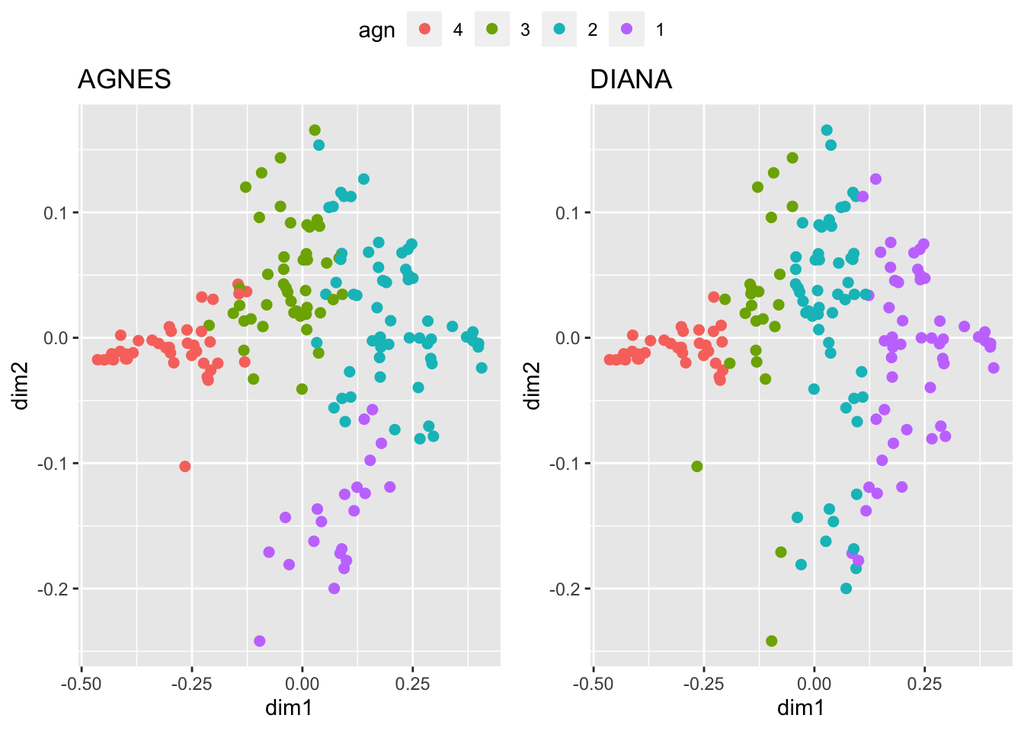

```r
library(ggpubr)

ggarrange(agnPlot, diaPlot,ncol = 2,common.legend = T)
```

- Annotating outliers:

Prepare labels:

```r
# If name of country in black list, use it, else get rid of it
LABELdia=ifelse(fromPy$Country%in%diaPoor,fromPy$Country,"")
LABELagn=ifelse(fromPy$Country%in%agnPoor,fromPy$Country,"")
```

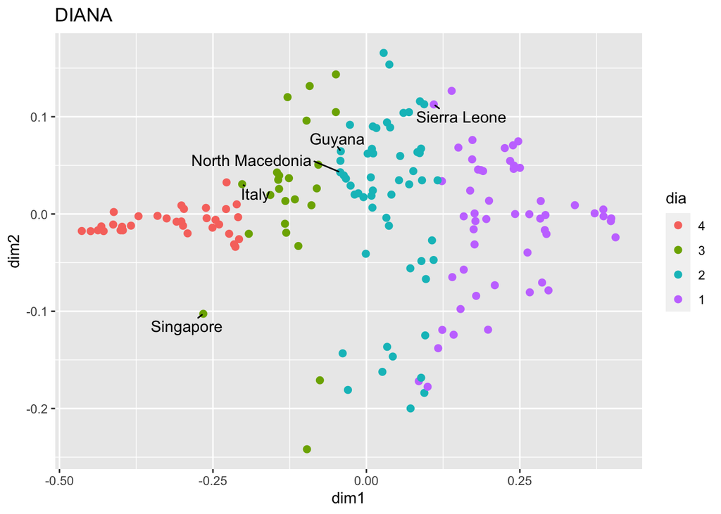

```r
library(ggrepel)
diaPlot + geom_text_repel(aes(label=LABELdia),max.overlaps = 50,min.segment.length = unit(0, 'lines'))
```

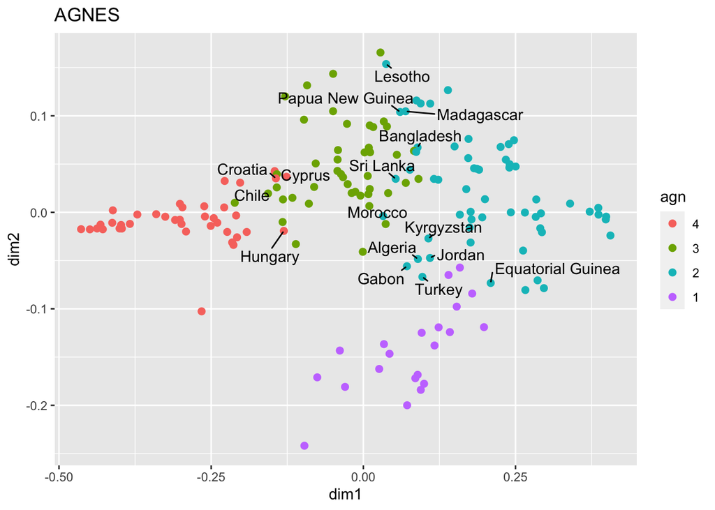

```r
agnPlot + geom_text_repel(aes(label=LABELagn),max.overlaps = 50,min.segment.length = unit(0, 'lines'))
```

- The Dendogram (for hierarchical approaches)

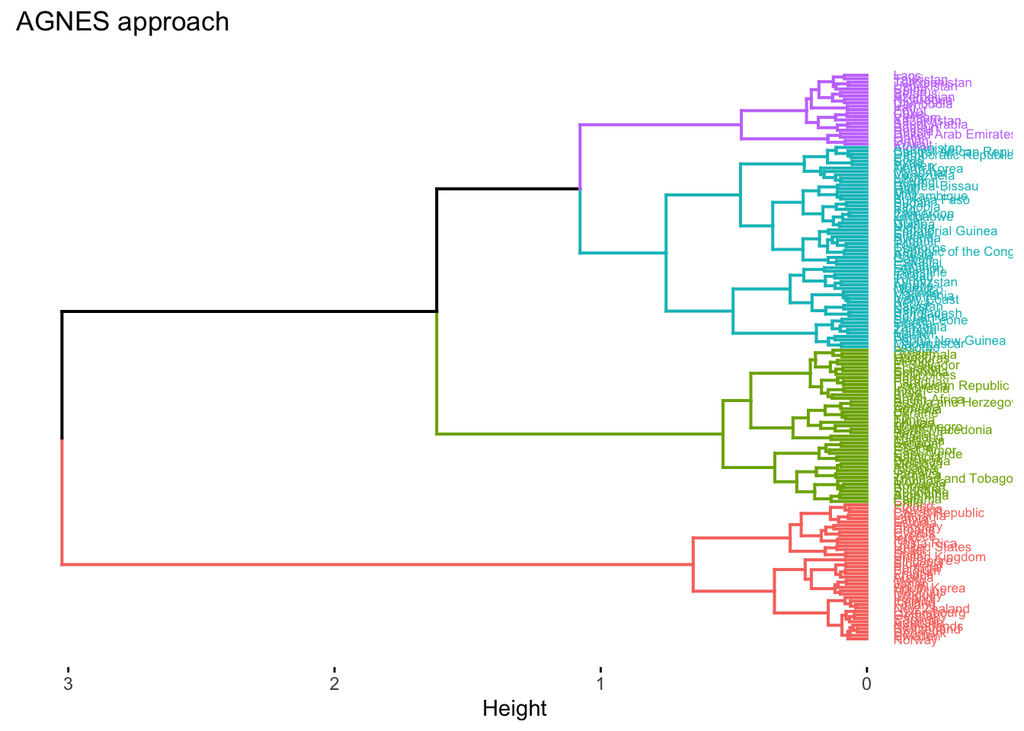

```r
fviz_dend(res.agnes,k=NumberOfClusterDesired, cex = 0.45, horiz = T,main = "AGNES approach")
```

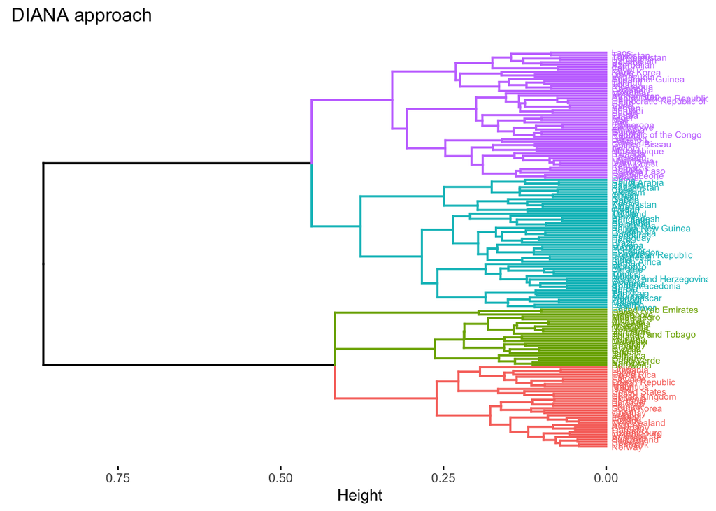

```r
fviz_dend(res.diana,k=NumberOfClusterDesired, cex = 0.45, horiz = T,main = "DIANA approach")
```

# FACTOR ANALYSIS

Simply speaking, this technique tries to express in one (or few) dimension(s) the behavior of several others. FA assumes that the several input variables have ‘something’ in common, there is something **latent** that the set of input variables represent.

Let me subset our original data frame:

```r
dataForFA=dataToCluster
```

```r
names(dataForFA)
```

```
##  [1] "Electoralprocessandpluralism" "Functioningofgovernment"
##  [3] "Politicalparticipation"       "Politicalculture"
##  [5] "Civilliberties"               "C1SecurityApparatus"
##  [7] "C2FactionalizedElites"        "C3GroupGrievance"
##  [9] "E1Economy"                    "E2EconomicInequality"
## [11] "E3HumanFlightandBrainDrain"   "P1StateLegitimacy"
## [13] "P2PublicServices"             "P3HumanRights"
## [15] "S1DemographicPressures"       "S2RefugeesandIDPs"
## [17] "X1ExternalIntervention"
```

```r
# esta es:
library(polycor)
corMatrix=polycor::hetcor(dataForFA)$correlations
```

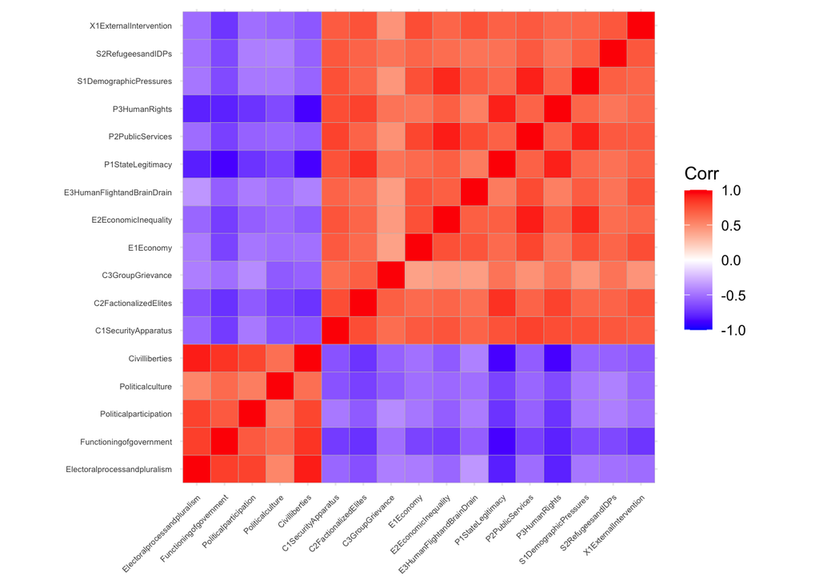

```r
library(ggcorrplot)

ggcorrplot(corMatrix) + theme(axis.text.x  = element_text(size = 5),axis.text.y  = element_text(size = 5))
```

```r
library(psych)
psych::KMO(corMatrix)
```

```
## Kaiser-Meyer-Olkin factor adequacy
## Call: psych::KMO(r = corMatrix)
## Overall MSA =  0.94
## MSA for each item =
## Electoralprocessandpluralism      Functioningofgovernment
##                         0.92                         0.96
##       Politicalparticipation             Politicalculture
##                         0.94                         0.96
##               Civilliberties          C1SecurityApparatus
##                         0.92                         0.95
##        C2FactionalizedElites             C3GroupGrievance
##                         0.94                         0.93
##                    E1Economy         E2EconomicInequality
##                         0.97                         0.94
##   E3HumanFlightandBrainDrain            P1StateLegitimacy
##                         0.96                         0.94
##             P2PublicServices                P3HumanRights
##                         0.91                         0.94
##       S1DemographicPressures            S2RefugeesandIDPs
##                         0.94                         0.94
##       X1ExternalIntervention
##                         0.94
```

```r
cortest.bartlett(corMatrix,n=nrow(dataForFA))$p.value>0.05
```

```
## [1] FALSE
```

```r
library(matrixcalc)

is.singular.matrix(corMatrix)
```

```
## [1] TRUE
```

```r
fa.parallel(dataForFA, fa = 'fa',correct = T,plot = F)
```

```
## Parallel analysis suggests that the number of factors =  2  and the number of components =  NA
```

```r
library(GPArotation)
resfa <- fa(dataForFA,
            nfactors = 2,
            cor = 'mixed',
            rotate = "varimax",
            fm="minres")
print(resfa$loadings)
```

```
##
## Loadings:
##                              MR1    MR2
## Electoralprocessandpluralism -0.215 -0.885
## Functioningofgovernment      -0.516 -0.744
## Politicalparticipation       -0.294 -0.743
## Politicalculture             -0.427 -0.570
## Civilliberties               -0.284 -0.930
## C1SecurityApparatus           0.735  0.465
## C2FactionalizedElites         0.584  0.645
## C3GroupGrievance              0.407  0.487
## E1Economy                     0.799  0.304
## E2EconomicInequality          0.795  0.380
## E3HumanFlightandBrainDrain    0.780  0.246
## P1StateLegitimacy             0.479  0.820
## P2PublicServices              0.885  0.330
## P3HumanRights                 0.466  0.800
## S1DemographicPressures        0.841  0.305
## S2RefugeesandIDPs             0.685  0.384
## X1ExternalIntervention        0.714  0.424
##
##                  MR1   MR2
## SS loadings    6.503 6.090
## Proportion Var 0.383 0.358
## Cumulative Var 0.383 0.741
```

```r
print(resfa$loadings,cutoff = 0.5)
```

```
##
## Loadings:
##                              MR1    MR2
## Electoralprocessandpluralism        -0.885
## Functioningofgovernment      -0.516 -0.744
## Politicalparticipation              -0.743
## Politicalculture                    -0.570
## Civilliberties                      -0.930
## C1SecurityApparatus           0.735
## C2FactionalizedElites         0.584  0.645
## C3GroupGrievance
## E1Economy                     0.799
## E2EconomicInequality          0.795
## E3HumanFlightandBrainDrain    0.780
## P1StateLegitimacy                    0.820
## P2PublicServices              0.885
## P3HumanRights                        0.800
## S1DemographicPressures        0.841
## S2RefugeesandIDPs             0.685
## X1ExternalIntervention        0.714
##
##                  MR1   MR2
## SS loadings    6.503 6.090
## Proportion Var 0.383 0.358
## Cumulative Var 0.383 0.741
```

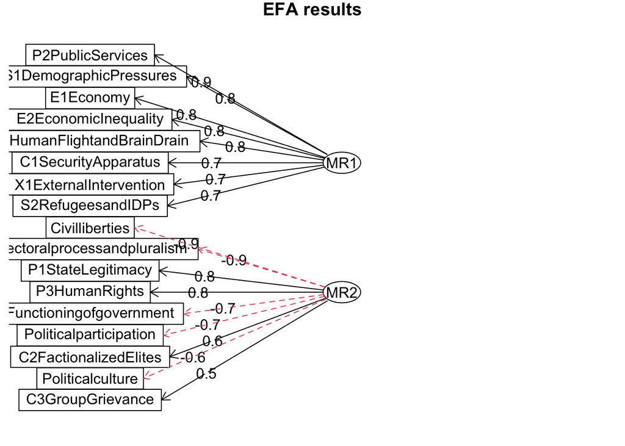

```r
fa.diagram(resfa,main = "EFA results")
```

```r
sort(resfa$communality)
```

```
##             C3GroupGrievance             Politicalculture
##                    0.4034923                    0.5068953
##            S2RefugeesandIDPs       Politicalparticipation
##                    0.6161475                    0.6393868
##   E3HumanFlightandBrainDrain       X1ExternalIntervention
##                    0.6690640                    0.6900314
##                    E1Economy          C1SecurityApparatus
##                    0.7306222                    0.7567213
##        C2FactionalizedElites         E2EconomicInequality
##                    0.7571858                    0.7754234
##       S1DemographicPressures      Functioningofgovernment
##                    0.8000285                    0.8202032
## Electoralprocessandpluralism                P3HumanRights
##                    0.8298193                    0.8575290
##             P2PublicServices            P1StateLegitimacy
##                    0.8920841                    0.9021443
##               Civilliberties
##                    0.9462528
```

```r
sort(resfa$complexity)
```

```
## Electoralprocessandpluralism               Civilliberties
##                     1.118078                     1.184325
##   E3HumanFlightandBrainDrain       S1DemographicPressures
##                     1.197527                     1.258663
##             P2PublicServices                    E1Economy
##                     1.273266                     1.283032
##       Politicalparticipation         E2EconomicInequality
##                     1.306003                     1.433648
##            S2RefugeesandIDPs                P3HumanRights
##                     1.572465                     1.607907
##            P1StateLegitimacy       X1ExternalIntervention
##                     1.611564                     1.628395
##          C1SecurityApparatus      Functioningofgovernment
##                     1.691080                     1.782136
##             Politicalculture             C3GroupGrievance
##                     1.853424                     1.939266
##        C2FactionalizedElites
##                     1.980759
```

```r
ps=c("P1StateLegitimacy","P2PublicServices","P3HumanRights")
notPs=setdiff(names(dataForFA),ps)
dataForFA=dataForFA[,notPs]
```

```r
# esta es:
library(polycor)
corMatrix=polycor::hetcor(dataForFA)$correlations
```

```r
library(psych)
psych::KMO(corMatrix)
```

```
## Kaiser-Meyer-Olkin factor adequacy
## Call: psych::KMO(r = corMatrix)
## Overall MSA =  0.93
## MSA for each item =
## Electoralprocessandpluralism      Functioningofgovernment
##                         0.88                         0.96
##       Politicalparticipation             Politicalculture
##                         0.93                         0.94
##               Civilliberties          C1SecurityApparatus
##                         0.89                         0.97
##        C2FactionalizedElites             C3GroupGrievance
##                         0.96                         0.90
##                    E1Economy         E2EconomicInequality
##                         0.96                         0.90
##   E3HumanFlightandBrainDrain       S1DemographicPressures
##                         0.95                         0.89
##            S2RefugeesandIDPs       X1ExternalIntervention
##                         0.93                         0.93
```

```r
cortest.bartlett(corMatrix,n=nrow(dataForFA))$p.value>0.05
```

```
## [1] FALSE
```

```r
library(matrixcalc)

is.singular.matrix(corMatrix)
```

```
## [1] FALSE
```

```r
fa.parallel(dataForFA, fa = 'fa',correct = T,plot = F)
```

```
## Parallel analysis suggests that the number of factors =  3  and the number of components =  NA
```

```r
library(GPArotation)
resfa <- fa(dataForFA,
            nfactors = 2,
            cor = 'mixed',
            rotate = "varimax",
            fm="minres")
print(resfa$loadings)
```

```
##
## Loadings:
##                              MR1    MR2
## Electoralprocessandpluralism -0.231  0.905
## Functioningofgovernment      -0.549  0.726
## Politicalparticipation       -0.305  0.749
## Politicalculture             -0.471  0.530
## Civilliberties               -0.316  0.932
## C1SecurityApparatus           0.767 -0.410
## C2FactionalizedElites         0.645 -0.578
## C3GroupGrievance              0.459 -0.436
## E1Economy                     0.812 -0.274
## E2EconomicInequality          0.767 -0.372
## E3HumanFlightandBrainDrain    0.791 -0.216
## S1DemographicPressures        0.817 -0.290
## S2RefugeesandIDPs             0.710 -0.359
## X1ExternalIntervention        0.755 -0.384
##
##                  MR1   MR2
## SS loadings    5.601 4.369
## Proportion Var 0.400 0.312
## Cumulative Var 0.400 0.712
```

```r
print(resfa$loadings,cutoff = 0.5)
```

```
##
## Loadings:
##                              MR1    MR2
## Electoralprocessandpluralism         0.905
## Functioningofgovernment      -0.549  0.726
## Politicalparticipation               0.749
## Politicalculture                     0.530
## Civilliberties                       0.932
## C1SecurityApparatus           0.767
## C2FactionalizedElites         0.645 -0.578
## C3GroupGrievance
## E1Economy                     0.812
## E2EconomicInequality          0.767
## E3HumanFlightandBrainDrain    0.791
## S1DemographicPressures        0.817
## S2RefugeesandIDPs             0.710
## X1ExternalIntervention        0.755
##
##                  MR1   MR2
## SS loadings    5.601 4.369
## Proportion Var 0.400 0.312
## Cumulative Var 0.400 0.712
```

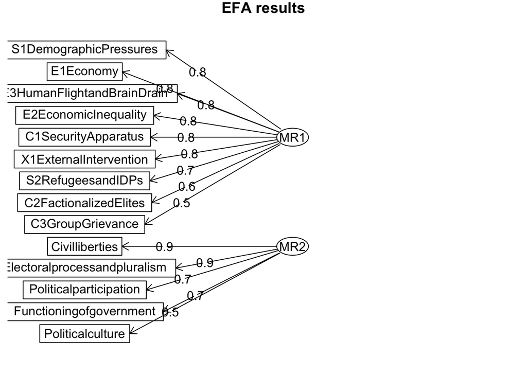

```r
fa.diagram(resfa,main = "EFA results")
```

```r
sort(resfa$communality)
```

```
##             C3GroupGrievance             Politicalculture
##                    0.4008682                    0.5022138
##            S2RefugeesandIDPs       Politicalparticipation
##                    0.6331073                    0.6544139
##   E3HumanFlightandBrainDrain       X1ExternalIntervention
##                    0.6723772                    0.7176851
##         E2EconomicInequality                    E1Economy
##                    0.7265745                    0.7338534
##        C2FactionalizedElites       S1DemographicPressures
##                    0.7506536                    0.7516278
##          C1SecurityApparatus      Functioningofgovernment
##                    0.7566777                    0.8290041
## Electoralprocessandpluralism               Civilliberties
##                    0.8723964                    0.9676060
```

```r
sort(resfa$complexity)
```

```
## Electoralprocessandpluralism   E3HumanFlightandBrainDrain
##                     1.129833                     1.147993
##                    E1Economy               Civilliberties
##                     1.224932                     1.226998
##       S1DemographicPressures       Politicalparticipation
##                     1.247477                     1.323574
##         E2EconomicInequality            S2RefugeesandIDPs
##                     1.445441                     1.480002
##       X1ExternalIntervention          C1SecurityApparatus
##                     1.484753                     1.529322
##      Functioningofgovernment             Politicalculture
##                     1.862299                     1.972808
##        C2FactionalizedElites             C3GroupGrievance
##                     1.976024                     1.994779
```